# MBQCFile

## MBQC Data:

#### Project Goals:

- Lot of variation in microbiome data that leads to a lack of reproducibility of experiments
- Standardize technology and methods for analyzing human microbial data

#### Project Details:

- Wanted to analyze the variation between methods and testing locations
- 2 Main Parts Looked At
  - Experimental Sample Handling
  - Bioinformatics Data Processing

#### Data Statistics:

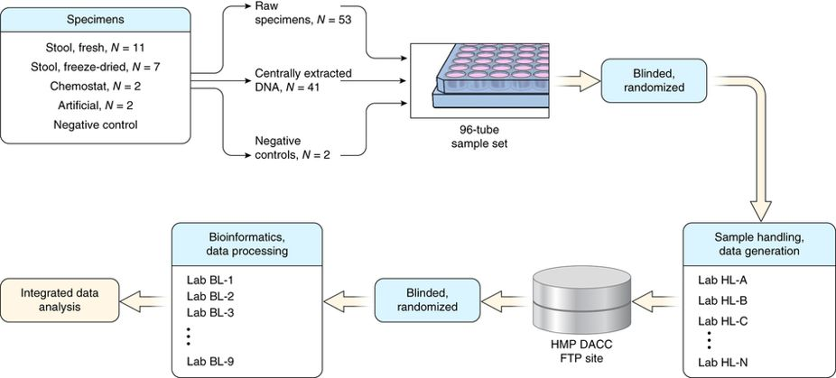

## Reading in Data

- Taking in 27211 taxa and 16140 samples from MBQC file
  - Create list of all classifications of taxa by parsing row names
  - Create taxa table with these classifications
  - Take tsv file convert it to data frame and then convert to matrix for phyloseq function
- Have statistics of all 16140 samples
  - Can subset data based on these stastics
  - Includes factors like age, BMI, sample type, processing lab, etc.
- RDS File Creation
  - Create file, MBQC_phyloseq.RDS, out of created phyloseq object
  - RDS file is easier to work with than excel file
  - Allows for manipulation of phyloseq object without creating it from scratch

### Sample Statistics

- Looked at:
  - Bioinformatics Lab
  - Gender
  - Health
  - Processing Lab
  - Sample Type
- Number of samples and proportion of row statistic

```r
##### SAMPLE #####
robo <- which(tf.ampli[56,] == 'Robogut')
robo.ampli <- tf.ampli[72:110, robo]
robogut <- length(robo)
fecart <- which(tf.ampli[56,] == 'Fecal artificial colony')
fecart.ampli <- tf.ampli[72:110, fecart]
fecalArtificial <- length(fecart)
frsh <- which(tf.ampli[56,] == 'Fresh')
fresh.ampli <- tf.ampli[72:110, frsh]
fresh <- length(frsh)
frz <- which(tf.ampli[56,] == 'Freeze-dried')
frz.ampli <- tf.ampli[72:110, frz]
freezeDried <- length(frz)
oral <- which(tf.ampli[56,] == 'Oral artificial colony')
oral.ampli <- tf.ampli[72:110, oral]
OralArt <- length(oral)

samp <- t(data.frame(tf.ampli[56,2:length(tf.ampli[56,])]))
sampT <- table(samp)
sampPro <- round(sampT/sum(sampT),2)
##################

##### GENDER #####
gend <- t(data.frame(tf.ampli[51,2:length(tf.ampli[51,])]))
gendT <- table(gend)
gendPro <- round(gendT/sum(gendT),2)
##################

##### PROCESSING LAB #####
lab <- t(data.frame(tf.ampli[24,2:length(tf.ampli[24,])]))
labT <- table(lab)
labPro <- round(labT/sum(labT),2)
###########################

##### HEALTH #####
health <- t(data.frame(tf.ampli[27,2:length(tf.ampli[27,])]))
healthT <- table(health)
healthPro <- round(healthT/sum(healthT),2)
##################

##### BNFO LAB #####
bnfo <- t(data.frame(tf.ampli[21,2:length(tf.ampli[21,])]))
bnfoT <- table(bnfo)
bnfoPro <- round(bnfoT/sum(bnfoT),2)
####################
```

### Summary Statistics Table

- Generated from sample statistics
- Includes number of samples and proportion of sample statistic
- Interpreting Numbers:
  - There were not 13,746 people as indicated by the gender section
  - Numbers are representative of the aliquots of the initial sample
  - Each sample is a small portion of a larger sample

```r
#Get rownames of each factor
names = c(rownames(sampT),rownames(gendT), rownames(labT),rownames(healthT), rownames(bnfoT))
hello <- matrix(c(sampT,gendT,labT,healthT,bnfoT,sampPro,gendPro,labPro,healthPro, bnfoPro), ncol=2)
colnames(hello) <- c("Number of Samples","Proportion")
rownames(hello) <- names
kable(hello) %>%
  kable_styling(bootstrap_options = c("striped", "hover"))%>%
  group_rows("Sample Type", 1, 6) %>%
  group_rows("Gender", 7, 9) %>%
  group_rows("Processing Lab", 10, 23) %>%
  group_rows("Condition", 24, 25) %>%
  group_rows("Bioinformatics Lab", 26, 33)
```

|  | Number of Samples | Proportion |
| --- | --- | --- |
| **Sample Type** |  |  |
| Fecal artificial colony | 1023 | 0.06 |
| Freeze-dried | 5075 | 0.31 |
| Fresh | 6946 | 0.43 |
| Oral artificial colony | 1016 | 0.06 |
| other | 345 | 0.02 |
| Robogut | 1725 | 0.11 |
| **Gender** |  |  |
| Female | 2458 | 0.18 |
| Male | 8322 | 0.61 |
| Unknown | 2966 | 0.22 |
| **Processing Lab** |  |  |
| HL-A | 354 | 0.04 |
| HL-B | 839 | 0.10 |
| HL-C | 776 | 0.09 |
| HL-D | 172 | 0.02 |
| HL-E | 566 | 0.06 |
| HL-F | 783 | 0.09 |
| HL-G | 402 | 0.05 |
| HL-H | 1269 | 0.14 |
| HL-I | 265 | 0.03 |
| HL-J | 2112 | 0.24 |
| HL-K | 423 | 0.05 |
| HL-L | 318 | 0.04 |
| HL-M | 120 | 0.01 |
| HL-N | 424 | 0.05 |
| **Condition** |  |  |
| Healthy | 6291 | 0.40 |
| Sick | 9494 | 0.60 |
| **Bioinformatics Lab** |  |  |
| BL-1 | 1978 | 0.12 |
| BL-2 | 2035 | 0.13 |
| BL-3 | 1793 | 0.11 |
| BL-4 | 2164 | 0.13 |
| BL-6 | 2130 | 0.13 |
| BL-8 | 2063 | 0.13 |
| BL-9A | 1970 | 0.12 |
| BL-9B | 2007 | 0.12 |

```r
#################

#####Two-Way Tables#####
twoLab <- table(bnfo,lab)
twoSL <- table(samp,lab)
twoSB <- table(samp, bnfo)
```

### Sample Type Pie Graph

- Fresh and Freeze-Dried samples predominate the overall distribution
- Not many artificially derived samples
- Could lead to more variability with smaller sample size

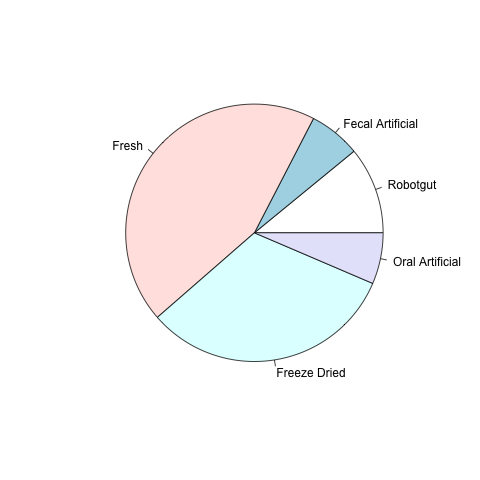

Sample Type Distribution

### Processing Lab and Bioinformatics Lab

- Table
  - Displays the number of samples of each bioinformatics lab with each processing lab
- Initial Observations
  - As can be seen, the number of samples if fairly consistent per each column
  - Few distinct exceptions
  - HL-D has almost half its entries as zeros
  - HL-A has some entries that are half the other entries (70, 35)

```r
kable(twoLab) %>%
  kable_styling(bootstrap_options = c("striped", "hover")) %>%
  column_spec(1, bold = T, border_right = T)
```

|  | HL-A | HL-B | HL-C | HL-D | HL-E | HL-F | HL-G | HL-H | HL-I | HL-J | HL-K | HL-L | HL-M | HL-N |
| --- | --- | --- | --- | --- | --- | --- | --- | --- | --- | --- | --- | --- | --- | --- |
| BL-1 | 70 | 106 | 97 | 0 | 71 | 100 | 51 | 159 | 0 | 265 | 53 | 53 | 15 | 53 |
| BL-2 | 35 | 105 | 97 | 0 | 71 | 99 | 51 | 159 | 53 | 265 | 53 | 53 | 15 | 53 |
| BL-3 | 34 | 105 | 97 | 0 | 71 | 95 | 48 | 159 | 0 | 259 | 53 | 0 | 15 | 53 |
| BL-4 | 70 | 105 | 97 | 44 | 71 | 99 | 51 | 159 | 53 | 265 | 53 | 53 | 15 | 53 |
| BL-6 | 35 | 105 | 97 | 44 | 71 | 99 | 51 | 159 | 53 | 265 | 53 | 53 | 15 | 53 |
| BL-8 | 40 | 104 | 97 | 40 | 69 | 91 | 46 | 156 | 53 | 264 | 52 | 53 | 15 | 53 |
| BL-9A | 70 | 103 | 97 | 0 | 71 | 99 | 51 | 159 | 0 | 264 | 53 | 53 | 15 | 53 |
| BL-9B | 0 | 106 | 97 | 44 | 71 | 101 | 53 | 159 | 53 | 265 | 53 | 0 | 15 | 53 |

### Sample Type and Processing Lab

- Table
  - Displays the number of samples of each sample type with each processing lab
- Initial Observations
  - Numbers are fairly spread out between each entry
  - Common proportions between sample type for each column
  - HL-J appears to process more samples than any other processing lab

```r
kable(twoSL) %>%
  kable_styling(bootstrap_options = c("striped", "hover")) %>%
  column_spec(1, bold = T, border_right = T)
```

|  | HL-A | HL-B | HL-C | HL-D | HL-E | HL-F | HL-G | HL-H | HL-I | HL-J | HL-K | HL-L | HL-M | HL-N |
| --- | --- | --- | --- | --- | --- | --- | --- | --- | --- | --- | --- | --- | --- | --- |
| Fecal artificial colony | 20 | 48 | 48 | 12 | 31 | 48 | 24 | 72 | 15 | 120 | 24 | 18 | 0 | 24 |
| Freeze-dried | 120 | 249 | 248 | 55 | 159 | 247 | 120 | 384 | 80 | 636 | 127 | 96 | 40 | 128 |
| Fresh | 151 | 398 | 336 | 70 | 280 | 345 | 193 | 597 | 125 | 998 | 200 | 150 | 32 | 200 |
| Oral artificial colony | 11 | 48 | 48 | 11 | 40 | 47 | 17 | 72 | 15 | 119 | 24 | 18 | 16 | 24 |
| other | 0 | 0 | 0 | 0 | 0 | 0 | 0 | 0 | 0 | 0 | 0 | 0 | 0 | 0 |
| Robogut | 52 | 96 | 96 | 24 | 56 | 96 | 48 | 144 | 30 | 239 | 48 | 36 | 32 | 48 |

### Sample Type and Bioinformatics Lab

- Table
  - Displays the number of samples of each sample type with each bioinformatics lab
- Initial Observations
  - Numbers are around equal for each column
  - Common proportions between sample type for each column

```r
kable(twoSB) %>%
  kable_styling(bootstrap_options = c("striped", "hover")) %>%
  column_spec(1, bold = T, border_right = T)
```

|  | BL-1 | BL-2 | BL-3 | BL-4 | BL-6 | BL-8 | BL-9A | BL-9B |
| --- | --- | --- | --- | --- | --- | --- | --- | --- |
| Fecal artificial colony | 125 | 129 | 115 | 137 | 135 | 130 | 125 | 127 |
| Freeze-dried | 624 | 641 | 567 | 678 | 666 | 651 | 622 | 626 |
| Fresh | 858 | 883 | 773 | 927 | 913 | 879 | 853 | 860 |
| Oral artificial colony | 124 | 128 | 114 | 135 | 134 | 129 | 123 | 129 |
| other | 35 | 36 | 31 | 54 | 54 | 48 | 35 | 52 |
| Robogut | 212 | 216 | 193 | 231 | 226 | 224 | 212 | 211 |

```r
########################
```

### Alpha Diversity

- Sample Handling
  - HL-E, HL-I, and HL-K show a widespread between its’ samples
  - This could point to contamination within the samples leading to this variance
- Bioinformatics Handling
  - Roughly same distribution across different labs
  - BL-3 has notably little to no variance

```r
#Read in phyloseq file for oral artificial community
oralseq <- readRDS("Oral_Physeq.rds")
#Take out all OTUs with reads < 1
GP <- prune_species(speciesSums(oralseq) > 0, oralseq)
```

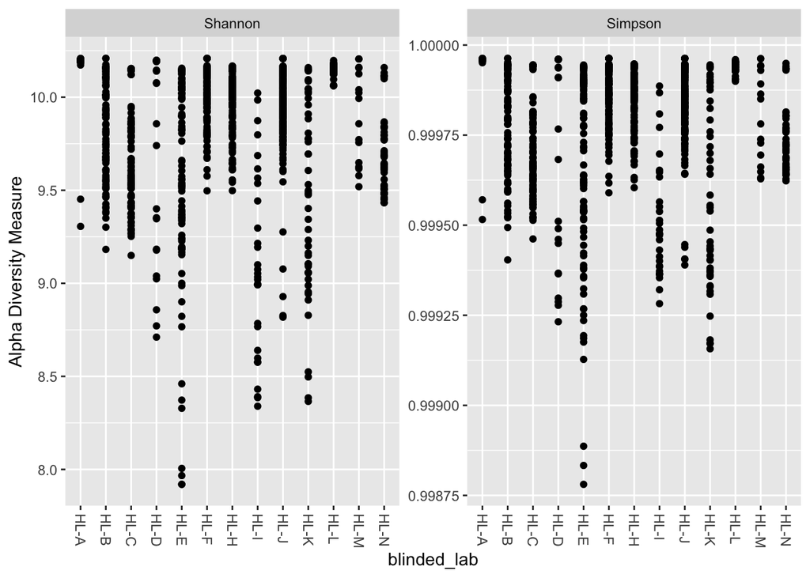

```r
#Plot Shannon and Simpson Diversity index
richness_measures <-c("Shannon", "Simpson")
plot_richness(GP, x="blinded_lab", measures=richness_measures)
```

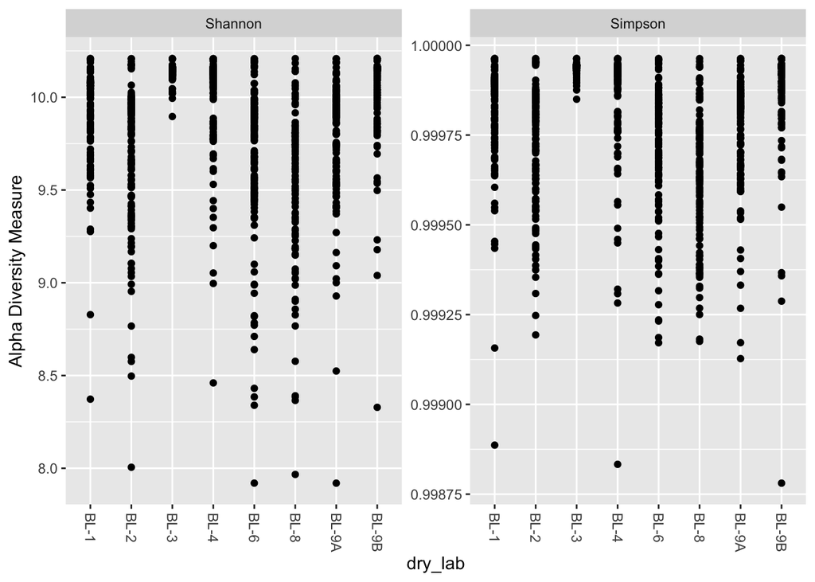

```r
plot_richness(GP, x="dry_lab", measures=richness_measures)
```

### Heatmap

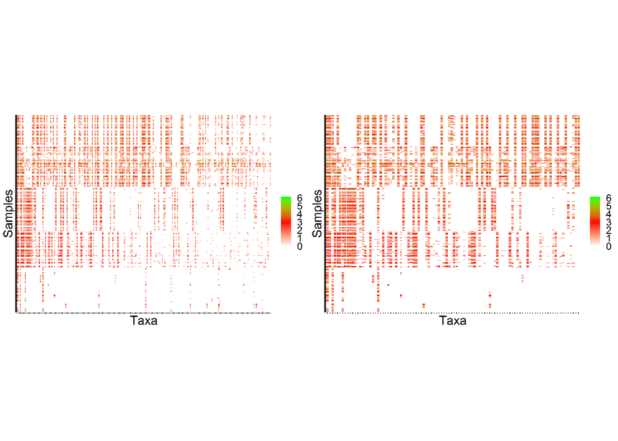

```r
img1 <-  rasterGrob(as.raster(readPNG("mockheatmap_top200taxa_600sam.png")), interpolate = FALSE)
img2 <-  rasterGrob(as.raster(readPNG("mockheatmap_top100taxa_600sam.png")), interpolate = FALSE)
grid.arrange(img1, img2, ncol = 2)
```

### Full MDS

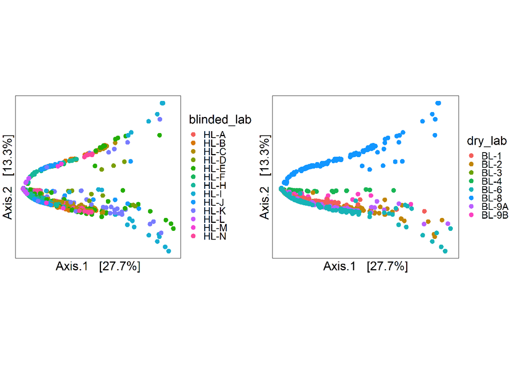

```r
img3 <-  rasterGrob(as.raster(readPNG("mds_hl_full.png")), interpolate = FALSE)
img4 <-  rasterGrob(as.raster(readPNG("mds_bl_full.png")), interpolate = FALSE)
grid.arrange(img3, img4, ncol = 2)
```

### Lab MDS

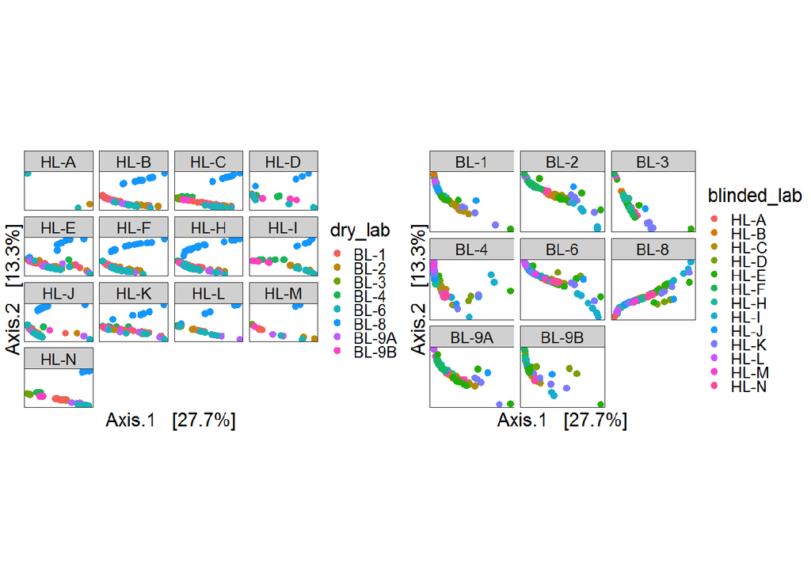

```r
img5 <-  rasterGrob(as.raster(readPNG("mds_hl.png")), interpolate = FALSE)
img6 <-  rasterGrob(as.raster(readPNG("mds_bl.png")), interpolate = FALSE)
grid.arrange(img5, img6, ncol = 2)
```